# Chapter 3

Ioanna Bouri

# Week 3

## Task 2: Reading the data

Let’s start by reading the data we preprocessed during the wrangling phase:

```r
data <- read.csv(file = "data/w3.csv", header = TRUE)
```

Let’s take look at the shape of the data:

```r
dim(data)
```

```
## [1] 370  35
```

And their variables:

```r
colnames(data)
```

```
##  [1] "school"     "sex"        "age"        "address"    "famsize"
##  [6] "Pstatus"    "Medu"       "Fedu"       "Mjob"       "Fjob"
## [11] "reason"     "nursery"    "internet"   "guardian"   "traveltime"
## [16] "studytime"  "failures"   "schoolsup"  "famsup"     "paid"
## [21] "activities" "higher"     "romantic"   "famrel"     "freetime"
## [26] "goout"      "Dalc"       "Walc"       "health"     "absences"
## [31] "G1"         "G2"         "G3"         "alc_use"    "high_use"
```

### Explaining the data

This data consists of student records in secondary education. We have a collection of variables that includes their grades, as well as social and demographic information. The students’ performance has been measured in two subjects: Portuguese (language) and Math. The focus of our analysis will be the impact of alcohol consumption levels to the students’ learning performance.

## Task 3: Intial hypotheses

This is no more than a hunch, and it shouldn’t be interpreted as anything more than that. I would like to initially focus more on variables that could explain a higher level of alcohol consumption. Namely, what are some factors that can lead a young student to higher alcohol consumptions levels? For this purpose, here are some variables I would like to investigate:

- **failures**: the number of past class failures might correlate to higher levels of alcohol consumption
- **goout**: going out with friends more often, might lead to more ‘social drinking’
- **famrel**: the quality of family relationships might be a reason that could facilitate drinking habits
- **absences**: number of school absences, might correlate with higher levels of alcohol consumption

## Task 4: Exploratory data analysis

Let’s start by visualizing an overview of the variables:

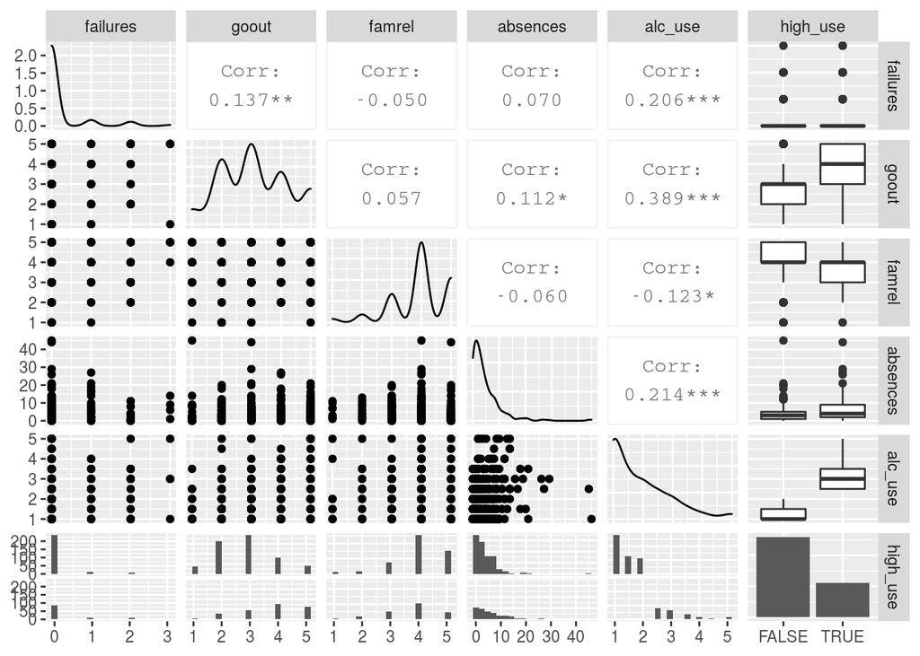

By plotting these pairwise correlations between the four selected variables, and the variables **alc_use** and **high use**, we can take a closer look into whether these variables actually correlate with higher levels of alcohol consumption. Indeed, we can see that we have significant reasons to believe that three out of the four initial hypotheses might be able to be validated with this data. We can observe a significant correlation between the variables of **failures**, **goout** and **absences**, with the variabe **alc_use**.

The variable **famrel** seems to have a negative correlation, as expected, meaning that the lower the scoring for family relations, the higher the level of **alc_use**. However, this correlation is not as significant as the other three, and we cannot be certain whether confident conclusions can be drawn from this data regarding this hypothesis.

## Task 5: Logistic Regression

Let’s fit a logistic regression classifier using the above variables!

```r
lr <- glm(high_use ~ failures + absences + goout + famrel, data = data, family = "binomial")
summary(lr)
```

```
##
## Call:
## glm(formula = high_use ~ failures + absences + goout + famrel,
##     family = "binomial", data = data)
##
## Deviance Residuals:
##     Min       1Q   Median       3Q      Max
## -1.8105  -0.7489  -0.5362   0.8436   2.4258
##
## Coefficients:
##             Estimate Std. Error z value Pr(>|z|)
## (Intercept) -2.35576    0.64261  -3.666 0.000246 ***
## failures     0.50165    0.22055   2.275 0.022933 *
## absences     0.07133    0.02188   3.261 0.001112 **
## goout        0.73896    0.12121   6.097 1.08e-09 ***
## famrel      -0.35348    0.13789  -2.563 0.010364 *
## ---
## Signif. codes:  0 '***' 0.001 '**' 0.01 '*' 0.05 '.' 0.1 ' ' 1
##
## (Dispersion parameter for binomial family taken to be 1)
##
##     Null deviance: 452.04  on 369  degrees of freedom
## Residual deviance: 377.45  on 365  degrees of freedom
## AIC: 387.45
##
## Number of Fisher Scoring iterations: 4
```